# Hard Work 9

```r
# This function will be useful later on.
makeTable9.3 <- function(thedata, nbest=1){

  if (nbest < 1 | nbest > dim(thedata)[2]-1){
    warning("nbest recoded to 1")
    nbest <- 1
  }

  cnames <- colnames(thedata)

  Yat <- grep("Y",cnames)

  if (length(Yat)>1)
    stop("Currently you have: ", paste(cnames[Yat], ", ", sep=""),
               " in your data set.\n There can be only one response variable.\n",
               sep="")

  colnames(thedata)[Yat] <- "Y"
  Xat <- grep("X",cnames)

  require("leaps")
  require("qpcR")

  reg <- regsubsets(thedata[,Xat],thedata[,Yat], nbest=nbest, nvmax=length(cnames)-1)

  regs <- summary(reg)

  models <- sapply(1:length(row.names(regs$which)), function(i){
    colnames(regs$which)[which(regs$which[i,])][-1]
  })

  pressdata <<- thedata

  PRESS <- sapply(models, function(model){
    tmpf <- formula(paste("Y~",
                          paste(model,
                                c(rep("+",length(model)-1), ""),
                                sep="",
                                collapse=""),
                          sep=""))
    tmp <- lm(tmpf, data=pressdata)
    tmp$call$formula <- eval(tmpf)
    PRESS(tmp, verbose=FALSE)$stat
  })

  n <- nrow(thedata)
  p <- as.numeric(row.names(regs$which))+1


  AIC <- regs$bic-log(n)*p-2*p


  AIC2 <- sapply(models, function(model){
    tmpf <- formula(paste("Y~",
                          paste(model,
                                c(rep("+",length(model)-1), ""),
                                sep="",
                                collapse=""),
                          sep=""))
    tmp <- lm(tmpf, data=pressdata)
    tmp$call$formula <- eval(tmpf)
    AIC(tmp)
  })

  tmp <- data.frame(p=p,
             model= sapply(1:length(models), function(i) {
                      paste(models[[i]], collapse=",")
                    }),
             SSEp=regs$rss,
             R2p=regs$rsq,
             R2ap=regs$adjr2,
             Cp=regs$cp,
             AICp=AIC2,
             SBCp=regs$bic,
             PRESSp=PRESS)

  rbind(data.frame(p=1,
                   model="(intercept)",
                   SSEp=regs$rss[1]/(1-regs$rsq[1]),
                   R2p=0,
                   R2ap=0,
                   Cp=NA,
                   AICp=NA,
                   SBCp=NA,
                   PRESSp=NA),tmp)
}
```

## Instructions

1. Study Sections 10.1 and 9.1-9.4 – “Added Variable Plots” and “Criteria for Model Selection.”
2. Attempt and submit at least {36} Hard Work Points by Saturday at 11:59 PM.  
   Over {50} gets you {+1} Final Exam Point.

## Reading Points {21} Possible

### Section 10.1 {4}{ 4 / 4 }

### Section 9.1 {3}{ 3 / 3 }

### Section 9.2 {4}{ 4 / 4 }

### Section 9.3 {6}{ 6 / 6 }

### Section 9.4 {4}{ 4 / 4 }

## Theory Points {3} Possible

### Problem 9.6 {3}{ / }

## Application Points {28} Possible

[Data Files](http://www.stat.ufl.edu/~rrandles/sta4210/Rclassnotes/data/textdatasets/index.html)

### Problem 9.9 {3}{ 3 / 3 }

```r
# Code to read in the data
# It has to be merged from the 1.20 and 8.15 data files.
p9.9 <- read.table("http://www.stat.ufl.edu/~rrandles/sta4210/Rclassnotes/data/textdatasets/KutnerData/Chapter%20%206%20Data%20Sets/CH06PR15.txt", header=FALSE)

# Give it nice column names for conevience:
colnames(p9.9) <- c("Y","X1","X2","X3")

# Show the first part of the data:
#head(p9.9)
```

**a.** Indicate which subset of predictor variables you would recommend as best for predicting patient satisfaction according to each of the following criteria.

```r
makeTable9.3(p9.9, nbest=3)
```

```
##   p       model      SSEp       R2p      R2ap        Cp     AICp      SBCp
## 1 1 (intercept) 13369.304 0.0000000 0.0000000        NA       NA        NA
## 2 2          X1  5093.915 0.6189843 0.6103248  8.353606 353.0717 -36.72879
## 3 2          X3  7814.391 0.4154975 0.4022134 35.245643 372.7561 -17.04445
## 4 2          X2  8509.044 0.3635387 0.3490737 42.112324 376.6735 -13.12698
## 5 3       X1,X3  4330.500 0.6760864 0.6610206  2.807204 347.6030 -40.36888
## 6 3       X1,X2  4613.000 0.6549559 0.6389073  5.599735 350.5100 -37.46189
## 7 3       X2,X3  7106.394 0.4684545 0.4437314 30.247056 370.3874 -17.58453
## 8 4    X1,X2,X3  4248.841 0.6821943 0.6594939  4.000000 348.7273 -37.41593
##     PRESSp
## 1       NA
## 2 5569.562
## 3 8451.432
## 4 9254.489
## 5 4902.751
## 6 5235.192
## 7 8115.912
## 8 5057.886
```

The “best” subset recommendations.

| Criteria | Criteria Score | Subset |
| --- | --- | --- |
| R2ap | 0.6610206 | X1, X3 |
| AICp | 347.6030 | X1, X3 |
| Cp | 2.807204 | X1, X3 |
| PRESSp | 4902.751 | X1, X3 |

**b.** Do the four criteria in part (a) identify the same best subset? does this always happen?

In this case, all four of the criteria support the same subset of variables, however this is not always the case.

**c.** Would forward step-wise regression have any advantages here as a screening procedure over the all-possible-regression procedure.

Looking at page 368, it appears that in this case, because the number of predictor variables is small, a backwards step-wise procedure would be more effective because the possibly inflated standard error. So in this case it might be best to use the all-possible-regression procedure.

In other situations, they are relatively the same and use similar criteria but it is more automated and would produce only one combination of variables instead of a subset of combinations.

But having a subset of variables would lead to more options to explore.

```r
# Stepwise Regression
library(MASS)
fit <- lm(Y~X1+X3+X2,data=p9.9)
step <- stepAIC(fit, direction="both")
```

```
## Start:  AIC=216.18
## Y ~ X1 + X3 + X2
##
##        Df Sum of Sq    RSS    AIC
## - X2    1     81.66 4330.5 215.06
## <none>              4248.8 216.19
## - X3    1    364.16 4613.0 217.97
## - X1    1   2857.55 7106.4 237.84
##
## Step:  AIC=215.06
## Y ~ X1 + X3
##
##        Df Sum of Sq    RSS    AIC
## <none>              4330.5 215.06
## + X2    1      81.7 4248.8 216.19
## - X3    1     763.4 5093.9 220.53
## - X1    1    3483.9 7814.4 240.21
```

```r
step$anova # display results
```

```
## Stepwise Model Path
## Analysis of Deviance Table
##
## Initial Model:
## Y ~ X1 + X3 + X2
##
## Final Model:
## Y ~ X1 + X3
##
##
##   Step Df Deviance Resid. Df Resid. Dev      AIC
## 1                         42   4248.841 216.1850
## 2 - X2  1 81.65905        43   4330.500 215.0607
```

### Problem 9.10 {3}{ 3 / 3 }

```r
# Code to read in the data
# It has to be merged from the 1.20 and 8.15 data files.
p9.10 <- read.table("http://www.stat.ufl.edu/~rrandles/sta4210/Rclassnotes/data/textdatasets/KutnerData/Chapter%20%209%20Data%20Sets/CH09PR10.txt", header=FALSE)

# Give it nice column names for conevience:
colnames(p9.10) <- c("Y","X1","X2","X3","X4")

# Show the first part of the data:
#head(p9.10)
```

**a.** Prepare stem and leaf plots of the test scores for each of the four newly developed aptitude tests. Are there ant noteworthy features in these plots? Comment.

```r
stem(p9.10$X1)
```

```
##
##   The decimal point is 1 digit(s) to the right of the |
##
##    6 | 248
##    8 | 4671468
##   10 | 014456902
##   12 | 0003
##   14 | 00
```

```r
stem(p9.10$X2)
```

```
##
##   The decimal point is 1 digit(s) to the right of the |
##
##    6 | 37
##    8 | 135947
##   10 | 127034789
##   12 | 01112599
```

```r
stem(p9.10$X3)
```

```
##
##   The decimal point is 1 digit(s) to the right of the |
##
##    8 | 0
##    9 | 01335556789
##   10 | 002356789
##   11 | 3456
```

```r
stem(p9.10$X4)
```

```
##
##   The decimal point is 1 digit(s) to the right of the |
##
##    7 | 48
##    8 | 03457889
##    9 | 0557
##   10 | 0223345889
##   11 | 0
```

X1 seems to be normal, however X2, X3, and X3 aren’t so normal.

Other than that, there doesn’t really appear to be too out of the ordinary.

**b.** Obtain the scatter plot matrix. Also obtain the correlation matrix of the $X$ variables. What do the scatter plots suggest about the nature of the functional relationship between the response variable $Y$ and each of the predictor variables? Are there any serious mutlicollinearity problems evident? Explain.

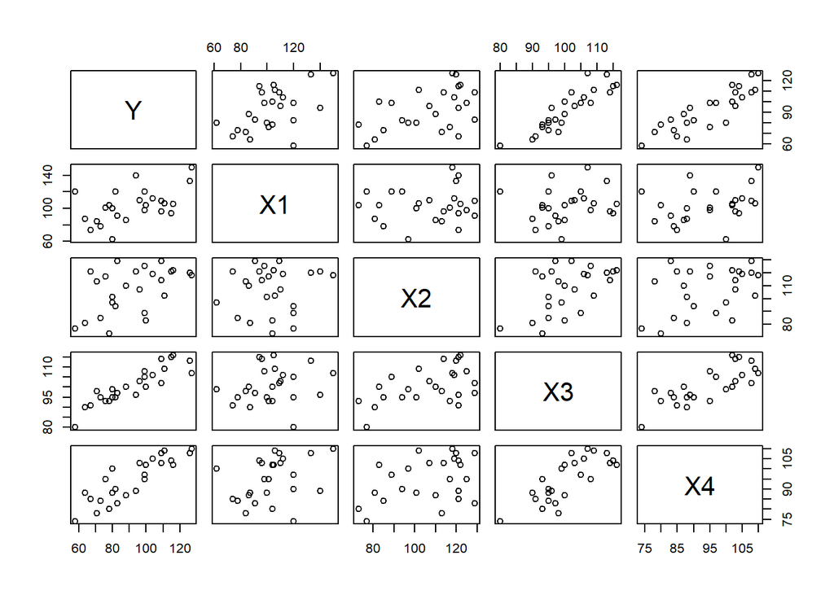

```r
pairs(Y~X1+X2+X3+X4, data=p9.10)
```

X3 and X4 really seem to have a strong positive correlation with Y. X1 might be able to help explain Y but it might contain an outlier.

```r
cor(p9.10)
```

```
##            Y        X1        X2        X3        X4
## Y  1.0000000 0.5144107 0.4970057 0.8970645 0.8693865
## X1 0.5144107 1.0000000 0.1022689 0.1807692 0.3266632
## X2 0.4970057 0.1022689 1.0000000 0.5190448 0.3967101
## X3 0.8970645 0.1807692 0.5190448 1.0000000 0.7820385
## X4 0.8693865 0.3266632 0.3967101 0.7820385 1.0000000
```

There may be an issue with multicollinearity with X3 and X4. It is possible that only one of these variables will be needed in the final model.

**c.** Fit the multiple regression function containing all four predictor variables as first-order terms. Does it appear that all predictor variables should be retained?

```r
p9.10.lm <- lm(Y ~ X1 + X2 + X3 + X4, data=p9.10)
summary(p9.10.lm)
```

```
##
## Call:
## lm(formula = Y ~ X1 + X2 + X3 + X4, data = p9.10)
##
## Residuals:
##     Min      1Q  Median      3Q     Max
## -5.9779 -3.4506  0.0941  2.4749  5.9959
##
## Coefficients:
##               Estimate Std. Error t value Pr(>|t|)
## (Intercept) -124.38182    9.94106 -12.512 6.48e-11 ***
## X1             0.29573    0.04397   6.725 1.52e-06 ***
## X2             0.04829    0.05662   0.853  0.40383
## X3             1.30601    0.16409   7.959 1.26e-07 ***
## X4             0.51982    0.13194   3.940  0.00081 ***
## ---
## Signif. codes:  0 '***' 0.001 '**' 0.01 '*' 0.05 '.' 0.1 ' ' 1
##
## Residual standard error: 4.099 on 20 degrees of freedom
## Multiple R-squared:  0.9629, Adjusted R-squared:  0.9555
## F-statistic: 129.7 on 4 and 20 DF,  p-value: 5.262e-14
```

It appears that X3, X1 and X4 are needed. in the model. X2 is not adding much information here.

Some more exploration could be done.

```r
mylm2 <- lm(Y ~ X3, data=p9.10)
summary(mylm2)
```

```
##
## Call:
## lm(formula = Y ~ X3, data = p9.10)
##
## Residuals:
##      Min       1Q   Median       3Q      Max
## -15.6908  -6.1073  -0.8528   2.6658  22.6010
##
## Coefficients:
##              Estimate Std. Error t value Pr(>|t|)
## (Intercept) -106.1328    20.4472  -5.191 2.91e-05 ***
## X3             1.9676     0.2021   9.736 1.26e-09 ***
## ---
## Signif. codes:  0 '***' 0.001 '**' 0.01 '*' 0.05 '.' 0.1 ' ' 1
##
## Residual standard error: 8.768 on 23 degrees of freedom
## Multiple R-squared:  0.8047, Adjusted R-squared:  0.7962
## F-statistic: 94.78 on 1 and 23 DF,  p-value: 1.264e-09
```

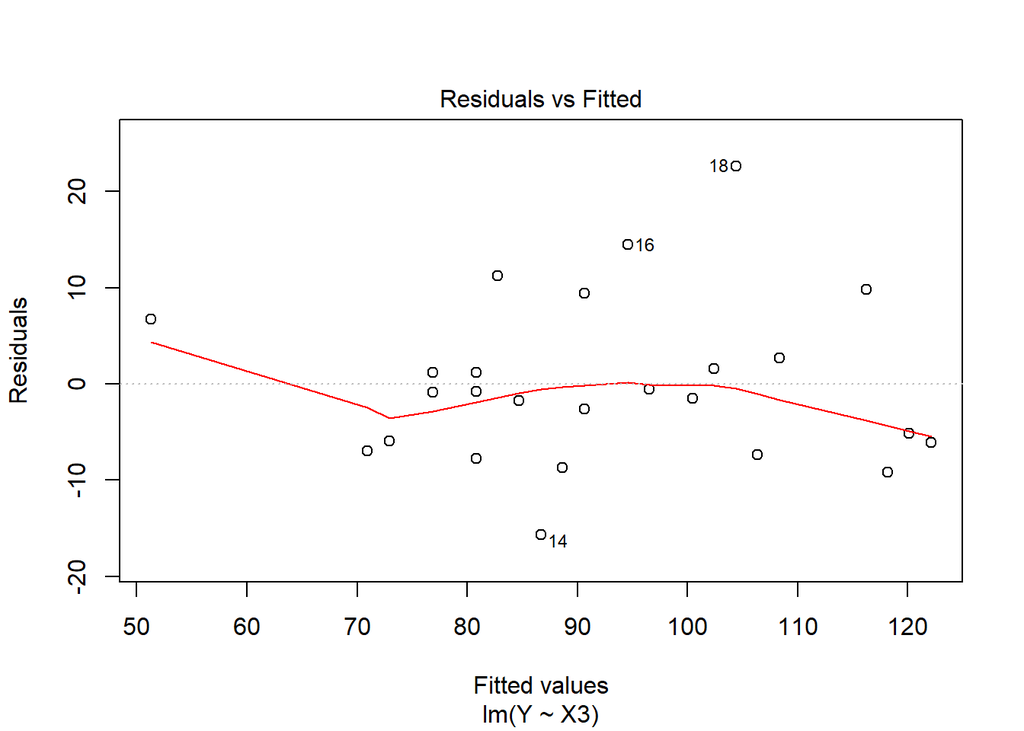

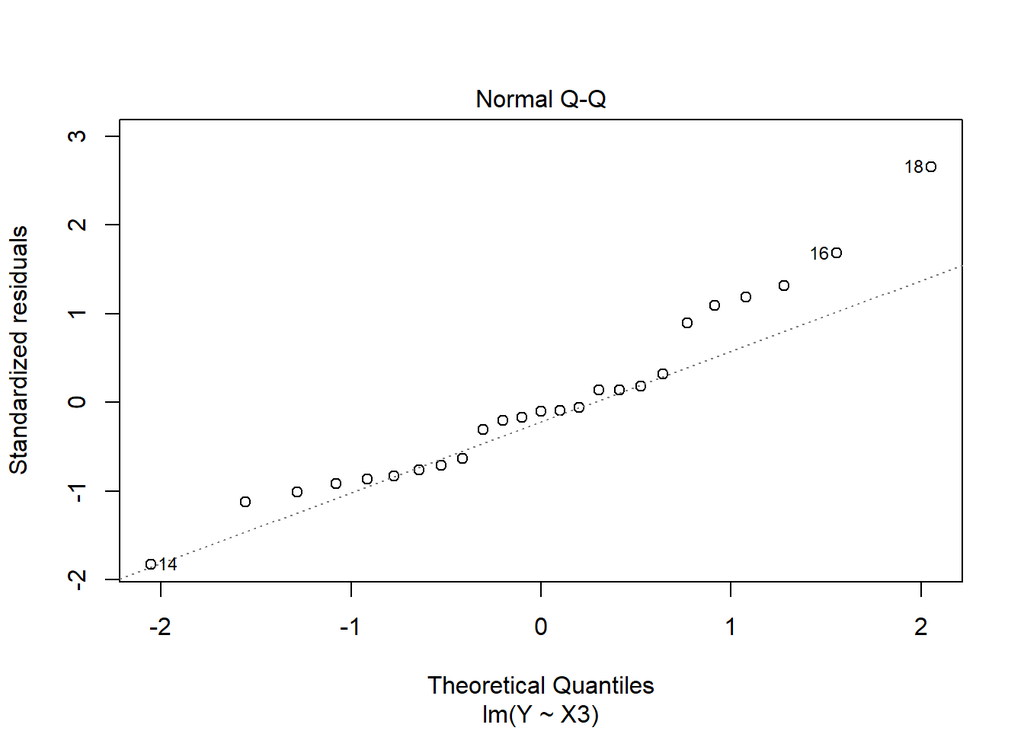

```r
plot(mylm2, which=1:2)
```

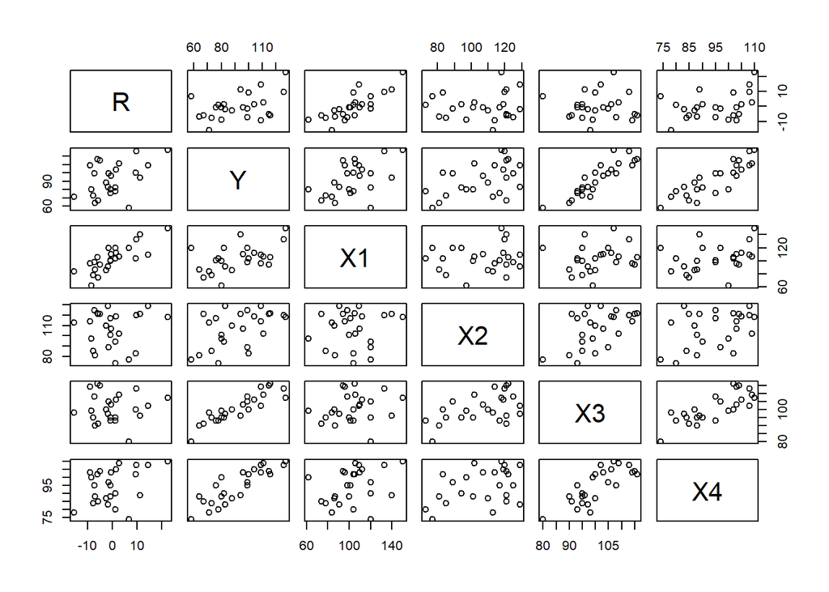

```r
pairs(cbind(R=mylm2$res, p9.10))
```

```r
mylm3 <- lm(Y ~ X3 + X1, data=p9.10)
summary(mylm3)
```

```
##
## Call:
## lm(formula = Y ~ X3 + X1, data = p9.10)
##
## Residuals:
##     Min      1Q  Median      3Q     Max
## -9.3489 -2.8086 -0.4546  2.8981 12.6469
##
## Coefficients:
##               Estimate Std. Error t value Pr(>|t|)
## (Intercept) -127.59569   12.68526  -10.06 1.09e-09 ***
## X3             1.82321    0.12307   14.81 6.31e-13 ***
## X1             0.34846    0.05369    6.49 1.58e-06 ***
## ---
## Signif. codes:  0 '***' 0.001 '**' 0.01 '*' 0.05 '.' 0.1 ' ' 1
##
## Residual standard error: 5.251 on 22 degrees of freedom
## Multiple R-squared:  0.933,  Adjusted R-squared:  0.9269
## F-statistic: 153.2 on 2 and 22 DF,  p-value: 1.222e-13
```

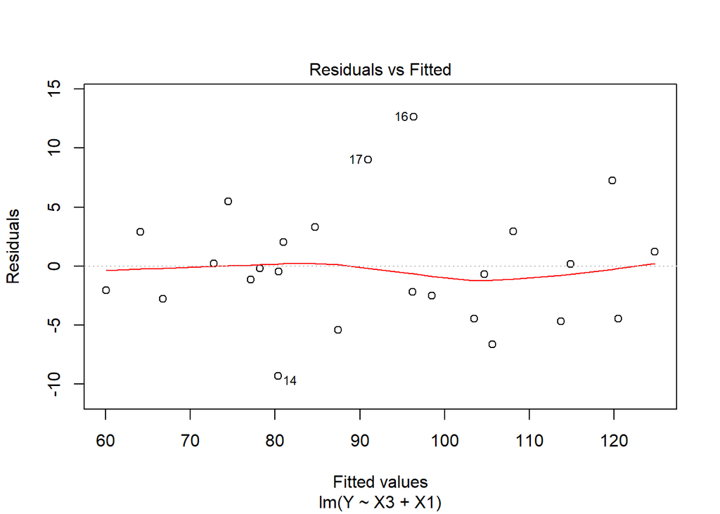

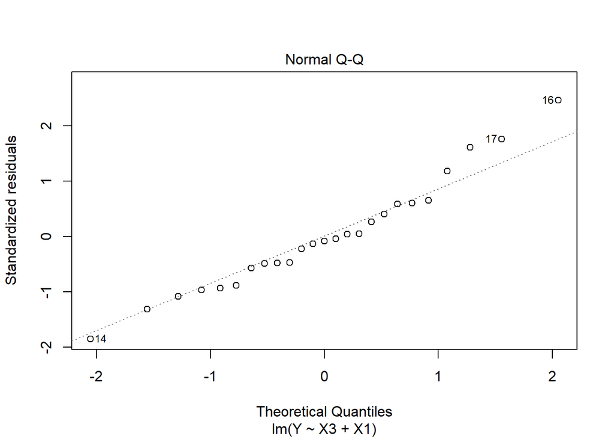

```r
plot(mylm3, which=1:2)
```

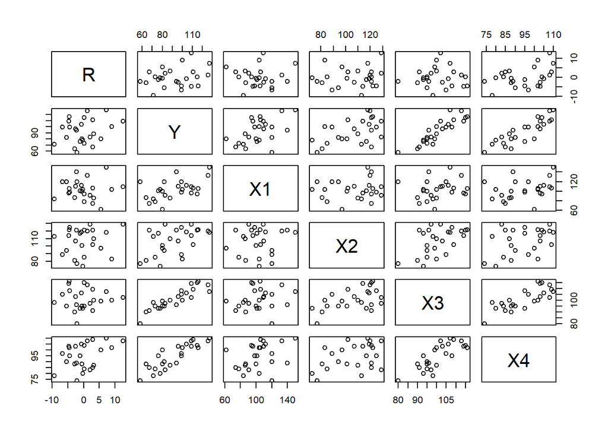

```r
pairs(cbind(R=mylm3$res, p9.10))
```

```r
makeTable9.3(p9.10)
```

```
##   p       model      SSEp       R2p      R2ap        Cp     AICp      SBCp
## 1 1 (intercept) 9054.0000 0.0000000 0.0000000        NA       NA        NA
## 2 2          X3 1768.0228 0.8047247 0.7962344 84.246496 183.4155 -34.39587
## 3 3       X1,X3  606.6574 0.9329956 0.9269043 17.112978 158.6741 -57.91831
## 4 4    X1,X3,X4  348.1970 0.9615422 0.9560482  3.727399 146.7942 -68.57933
## 5 5 X1,X2,X3,X4  335.9775 0.9628918 0.9554702  5.000000 147.9011 -66.25356
##      PRESSp
## 1        NA
## 2 2064.5976
## 3  760.9744
## 4  471.4520
## 5  518.9885
```

```r
mylm4 <- lm(Y ~ X3 + X1 +X4, data=p9.10)
summary(mylm4)
```

```
##
## Call:
## lm(formula = Y ~ X3 + X1 + X4, data = p9.10)
##
## Residuals:
##     Min      1Q  Median      3Q     Max
## -5.4579 -3.1563 -0.2057  1.8070  6.6083
##
## Coefficients:
##               Estimate Std. Error t value Pr(>|t|)
## (Intercept) -124.20002    9.87406 -12.578 3.04e-11 ***
## X3             1.35697    0.15183   8.937 1.33e-08 ***
## X1             0.29633    0.04368   6.784 1.04e-06 ***
## X4             0.51742    0.13105   3.948 0.000735 ***
## ---
## Signif. codes:  0 '***' 0.001 '**' 0.01 '*' 0.05 '.' 0.1 ' ' 1
##
## Residual standard error: 4.072 on 21 degrees of freedom
## Multiple R-squared:  0.9615, Adjusted R-squared:  0.956
## F-statistic:   175 on 3 and 21 DF,  p-value: 5.16e-15
```

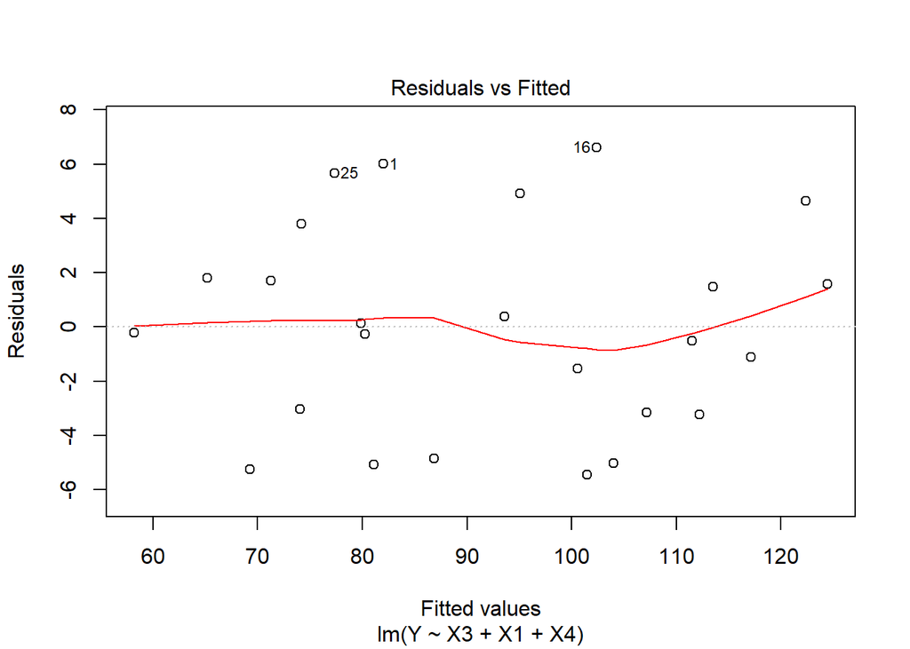

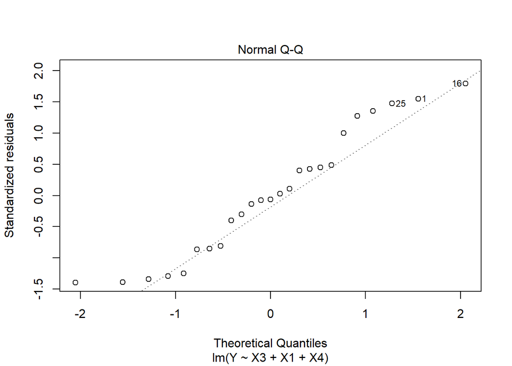

```r
plot(mylm4, which=1:2)
```

### Problem 9.11 {2}{ 2 / 2 }

```r
# Use the data p9.10 for this one.
```

**a.** Using only first order terms for the predictor variables in the pool of potential X variables, find the four best subset regression models according to the R2ap criterion.

```r
makeTable9.3(p9.10, nbest=8)
```

```
##   p       model      SSEp       R2p      R2ap        Cp     AICp      SBCp
## 1 1 (intercept) 9054.0000 0.0000000 0.0000000        NA       NA        NA
## 2 2          X3 1768.0228 0.8047247 0.7962344 84.246496 183.4155 -34.39587
## 3 3       X1,X3  606.6574 0.9329956 0.9269043 17.112978 158.6741 -57.91831
## 4 4    X1,X3,X4  348.1970 0.9615422 0.9560482  3.727399 146.7942 -68.57933
## 5 5 X1,X2,X3,X4  335.9775 0.9628918 0.9554702  5.000000 147.9011 -66.25356
##      PRESSp
## 1        NA
## 2 2064.5976
## 3  760.9744
## 4  471.4520
## 5  518.9885
```

| Subset | R^2_ap |
| --- | --- |
| X1, X3, X4 | 0.9560482 |
| X1, X2, X3, X4 | 0.9554702 |
| X1, X3 | 0.9269043 |
| X1, X2, X3 | 0.9246779 |

**b.** Since there is relatively little difference in R2ap for the four best models, what other criteria would you use to help in the selection of the best model? Discuss.

One could look at the residual standard error for each model. The lower the error better. One could also at residual and QQ plots. If the plots indicate a transformation then that could prove to be the better model where as the R2ap will not account for it.

### Case Study 9.29 {10}{ 8 / 9 }

```r
# Code to read in the data
# It has to be merged from the 1.20 and 8.15 data files.
p9.29 <- read.table("http://www.stat.ufl.edu/~rrandles/sta4210/Rclassnotes/data/textdatasets/KutnerData/Appendix%20C%20Data%20Sets/APPENC06.txt", header=FALSE)

# Give it nice column names for conevience:
colnames(p9.29) <- c("ID","Y",paste("X",1:6, sep=""))

# Show the first part of the data:
#head(p9.29)

p29 <- p9.29
p29$X6 <- as.factor(p29$X6)
p29$X5 <- as.factor(p29$X5)
p29$X4 <- as.factor(p29$X4)
p29$X2 <- as.factor(p29$X2)
str(p29)
```

```
## 'data.frame':    73 obs. of  8 variables:
##  $ ID: int  1 2 3 4 5 6 7 8 9 10 ...
##  $ Y : int  1 2 7 2 1 10 10 1 1 6 ...
##  $ X1: int  12 18 26 28 36 45 36 18 25 28 ...
##  $ X2: Factor w/ 13 levels "1","2","3","4",..: 1 1 1 1 1 1 1 2 2 2 ...
##  $ X3: int  3 6 9 12 15 18 21 3 6 9 ...
##  $ X4: Factor w/ 2 levels "0","1": 1 1 1 1 1 2 2 1 1 1 ...
##  $ X5: Factor w/ 2 levels "2001","2002": 1 1 1 1 2 2 2 1 1 1 ...
##  $ X6: Factor w/ 4 levels "1","2","3","4": 1 2 3 4 1 2 3 1 2 3 ...
```

First we will look at a pairs plot.

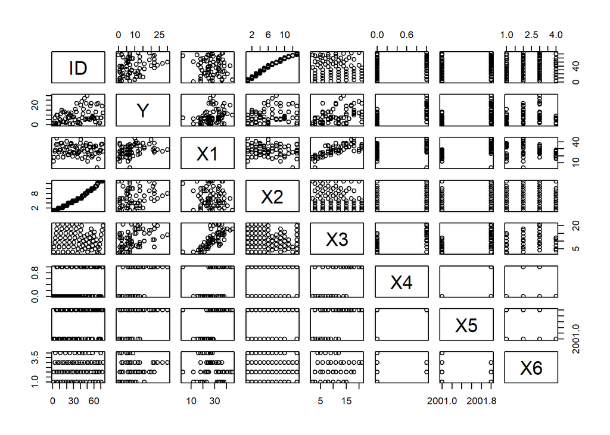

```r
pairs(p9.29)
```

All of them seem to have some promise.

```r
makeTable9.3(p9.29)
```

```
##   p             model     SSEp       R2p      R2ap       Cp     AICp
## 1 1       (intercept) 3612.877 0.0000000 0.0000000       NA       NA
## 2 2                X4 1908.079 0.4718672 0.4644287 4.179345 451.3927
## 3 3             X2,X4 1871.979 0.4818592 0.4670552 4.794829 451.9983
## 4 4          X4,X5,X6 1806.355 0.5000230 0.4782849 4.278015 451.3933
## 5 5       X3,X4,X5,X6 1757.680 0.5134958 0.4848779 4.411192 451.3992
## 6 6    X1,X3,X4,X5,X6 1722.926 0.5231151 0.4875267 5.078317 451.9414
## 7 7 X1,X2,X3,X4,X5,X6 1720.884 0.5236803 0.4803785 7.000000 453.8548
##        SBCp   PRESSp
## 1        NA       NA
## 2 -38.02283 2038.266
## 3 -35.12673 2045.232
## 4 -33.44126 2000.077
## 5 -31.14491 2049.526
## 6 -28.31229 2115.172
## 7 -24.10841 2145.989
```

X4 is always within one of the models so we will go with that to start off with.

```r
p29.lm <- lm(Y ~ X4, data=p9.29)
summary(p29.lm)
```

```
##
## Call:
## lm(formula = Y ~ X4, data = p9.29)
##
## Residuals:
##      Min       1Q   Median       3Q      Max
## -12.5385  -3.4468  -0.4468   3.4615  14.4615
##
## Coefficients:
##             Estimate Std. Error t value Pr(>|t|)
## (Intercept)   5.4468     0.7562   7.203 4.97e-10 ***
## X4           10.0917     1.2671   7.965 1.94e-11 ***
## ---
## Signif. codes:  0 '***' 0.001 '**' 0.01 '*' 0.05 '.' 0.1 ' ' 1
##
## Residual standard error: 5.184 on 71 degrees of freedom
## Multiple R-squared:  0.4719, Adjusted R-squared:  0.4644
## F-statistic: 63.44 on 1 and 71 DF,  p-value: 1.945e-11
```

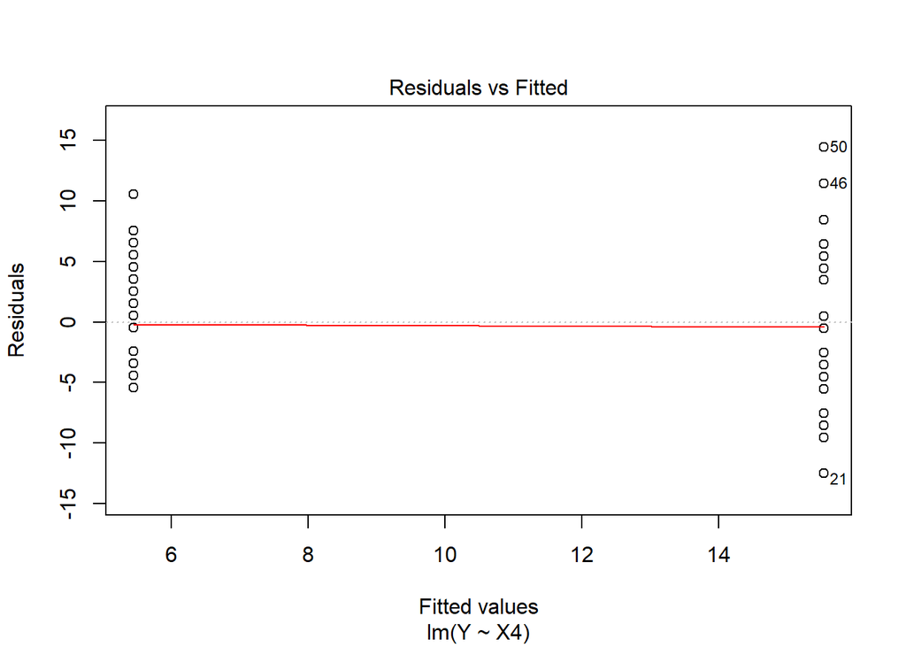

```r
plot(p29.lm, which=1)
```

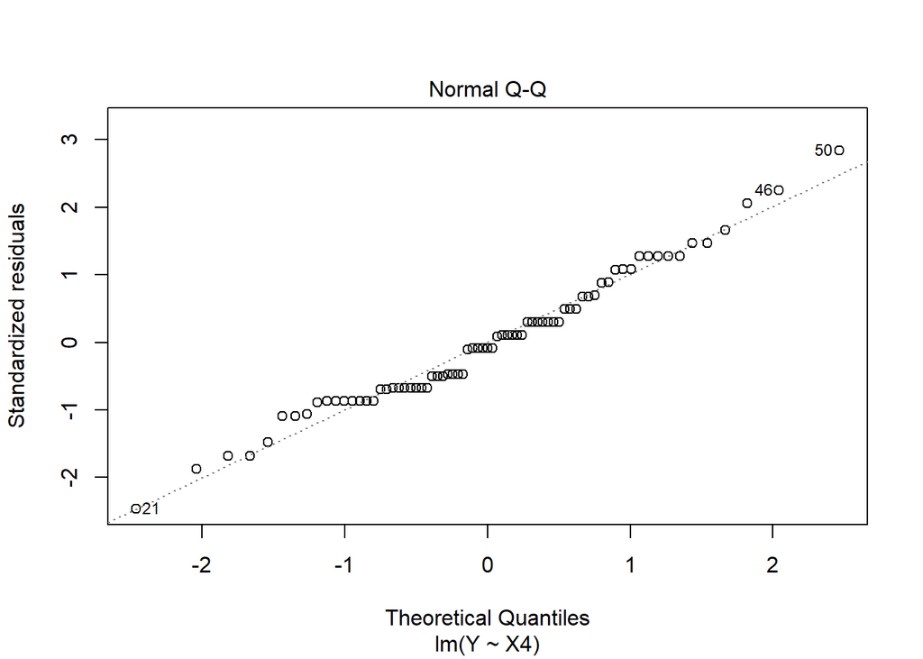

```r
plot(p29.lm, which=2)
```

X4 does show a lot of promise as being a useful variable.

Normallity of the error terms is looking great but variance not so much.

However, considering that this is just one variable that is qualitative it will not matter quite so much because using only X4 basically turns this an independent t test.

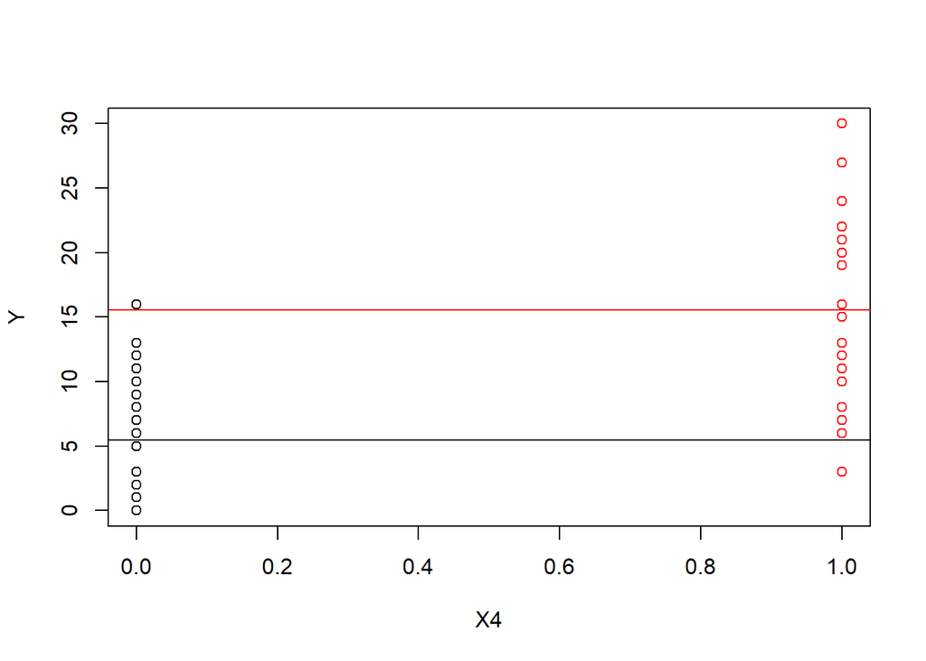

```r
plot(Y ~ X4, data=p9.29, col=X4+1)
abline(5.4468, 0, col="black")
abline(5.4468 + 10.0917, 0, col="red")
```

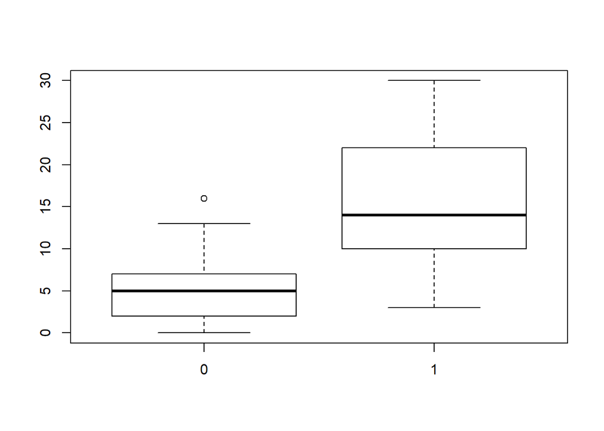

```r
boxplot(Y~X4, data=p9.29)
```

```r
favstats(Y ~ X4, data=p9.29)
```

```
##   X4 min    Q1 median    Q3 max      mean       sd  n missing
## 1  0   0  2.00      5  7.00  16  5.446809 3.838073 47       0
## 2  1   3 10.25     14 21.75  30 15.538462 7.015587 26       0
```

Lets see if we can add more to this.

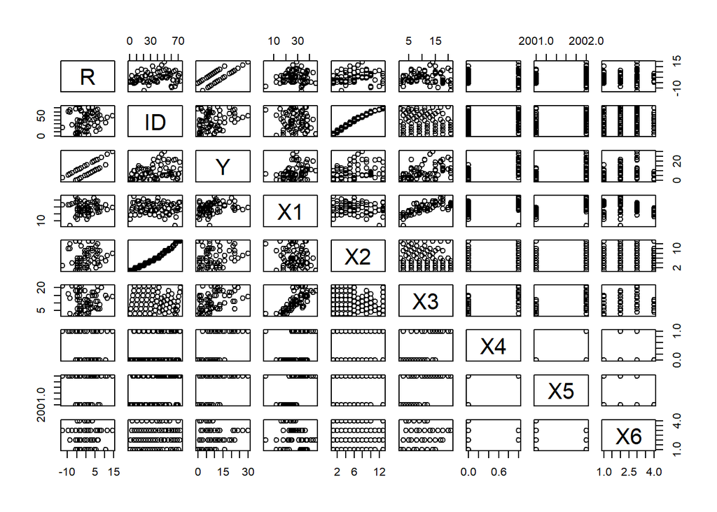

```r
pairs(cbind(R=p29.lm$res, p9.29))
```

X1, X3 or X5 might be of some use.

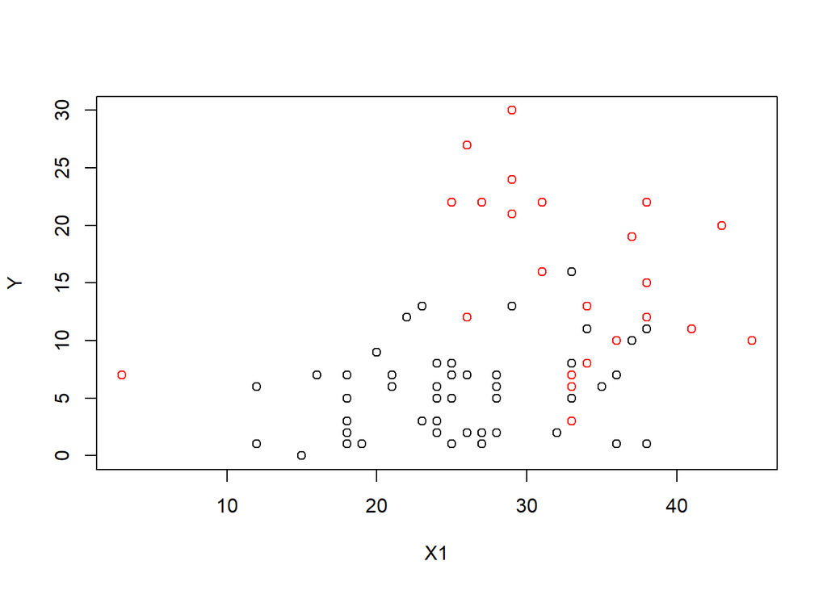

```r
plot(Y ~ X1, col=X4+1, data=p9.29)
```

Adding X1 into the picture with the color of X4 shows some interesting patterns. Unfortunatly we have an outlier that will porve to be an challenging.

Lets fit X1 into the model with an interaction term.

```r
p9.29.lm2 <- lm(Y ~ X1 + X4 + X1:X4, data=p9.29)
summary(p9.29.lm2)
```

```
##
## Call:
## lm(formula = Y ~ X1 + X4 + X1:X4, data = p9.29)
##
## Residuals:
##      Min       1Q   Median       3Q      Max
## -12.5154  -3.4643  -0.3012   3.0069  14.3132
##
## Coefficients:
##             Estimate Std. Error t value Pr(>|t|)
## (Intercept)   1.4801     2.9300   0.505  0.61506
## X1            0.1571     0.1121   1.401  0.16561
## X4           15.4493     5.2522   2.941  0.00444 **
## X1:X4        -0.1999     0.1721  -1.162  0.24937
## ---
## Signif. codes:  0 '***' 0.001 '**' 0.01 '*' 0.05 '.' 0.1 ' ' 1
##
## Residual standard error: 5.181 on 69 degrees of freedom
## Multiple R-squared:  0.4873, Adjusted R-squared:  0.465
## F-statistic: 21.86 on 3 and 69 DF,  p-value: 4.653e-10
```

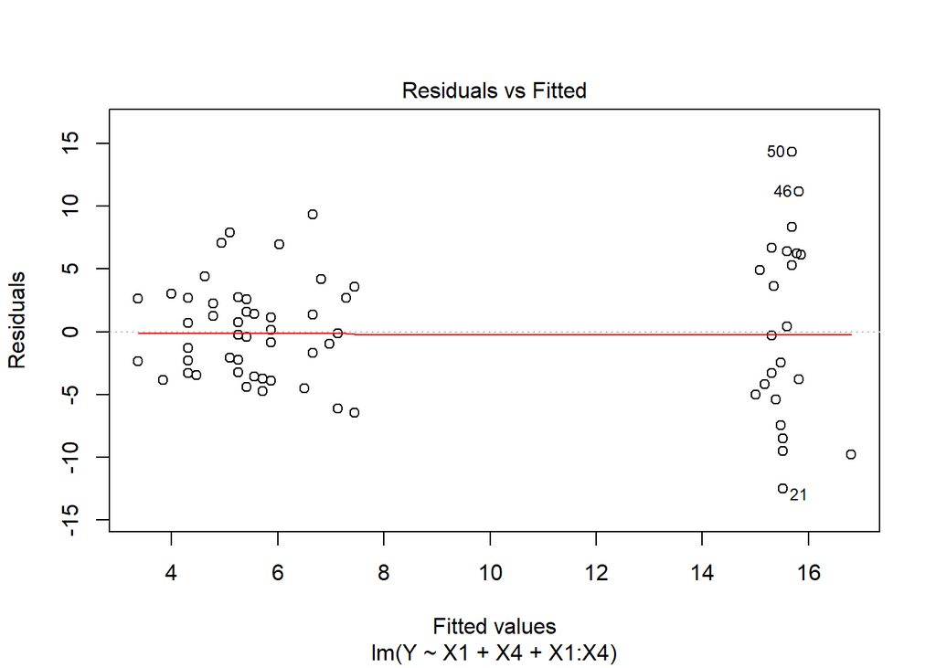

```r
plot(p9.29.lm2, which=1)
```

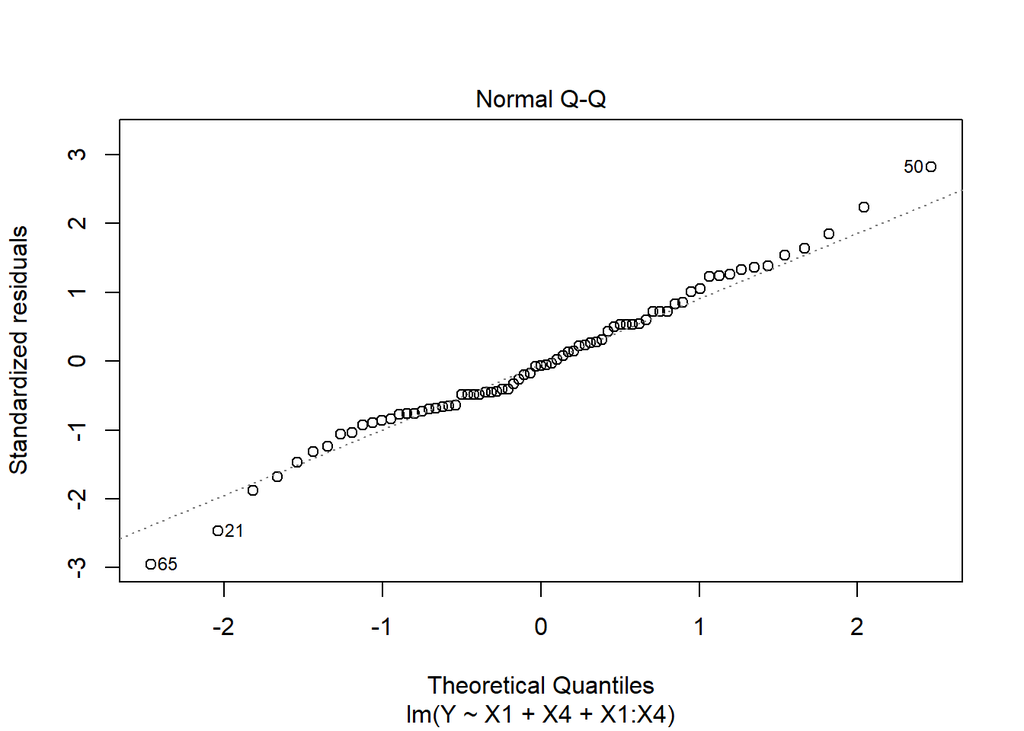

```r
plot(p9.29.lm2, which=2)
```

The residuals still are not great. The outlier as caused the regression line to miss the data very badly. Adding X1 did not seem to have much of an effect.

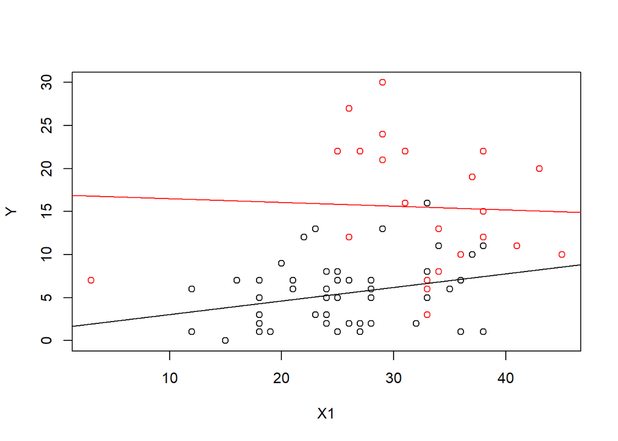

```r
plot(Y ~ X1, col=X4+1, data=p9.29)
b<- p9.29.lm2$coefficients
abline(b[1], b[2], col="black")
abline(b[1]+b[3], b[2]+b[4], col="red")
```

```r
p9.29.lm3 <- lm(Y ~ X4 + X1, data=p9.29)
summary(p9.29.lm3)
```

```
##
## Call:
## lm(formula = Y ~ X4 + X1, data = p9.29)
##
## Residuals:
##      Min       1Q   Median       3Q      Max
## -12.5774  -3.5729  -0.3561   3.1336  14.7117
##
## Coefficients:
##             Estimate Std. Error t value Pr(>|t|)
## (Intercept)  3.62192    2.28277   1.587    0.117
## X4           9.57095    1.41044   6.786 3.06e-09 ***
## X1           0.07226    0.08526   0.847    0.400
## ---
## Signif. codes:  0 '***' 0.001 '**' 0.01 '*' 0.05 '.' 0.1 ' ' 1
##
## Residual standard error: 5.194 on 70 degrees of freedom
## Multiple R-squared:  0.4772, Adjusted R-squared:  0.4623
## F-statistic: 31.95 on 2 and 70 DF,  p-value: 1.383e-10
```

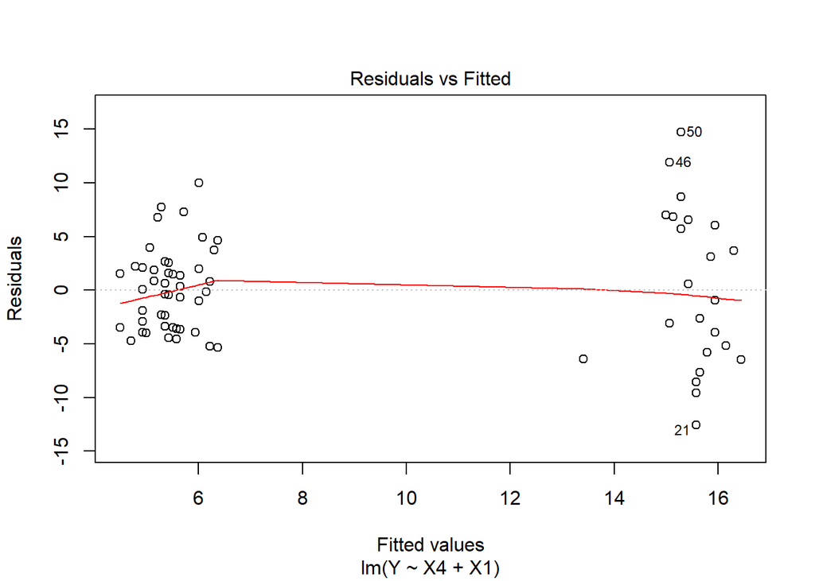

```r
plot(p9.29.lm3, which=1)
```

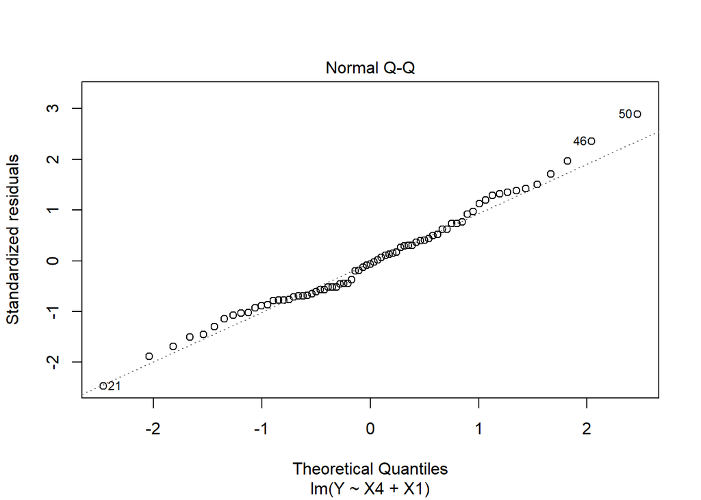

```r
plot(p9.29.lm3, which=2)
```

Leaving out the interaction term does not seem to much good either.

Lets try X3

```r
p9.29.lm4 <- lm(Y ~ X4 + X3, data=p9.29)
summary(p9.29.lm4)
```

```
##
## Call:
## lm(formula = Y ~ X4 + X3, data = p9.29)
##
## Residuals:
##      Min       1Q   Median       3Q      Max
## -12.6426  -3.5794  -0.4431   3.4353  14.4938
##
## Coefficients:
##             Estimate Std. Error t value Pr(>|t|)
## (Intercept)  5.28725    1.38115   3.828 0.000278 ***
## X4           9.94630    1.65222   6.020 7.22e-08 ***
## X3           0.01948    0.14067   0.138 0.890267
## ---
## Signif. codes:  0 '***' 0.001 '**' 0.01 '*' 0.05 '.' 0.1 ' ' 1
##
## Residual standard error: 5.22 on 70 degrees of freedom
## Multiple R-squared:  0.472,  Adjusted R-squared:  0.4569
## F-statistic: 31.29 on 2 and 70 DF,  p-value: 1.958e-10
```

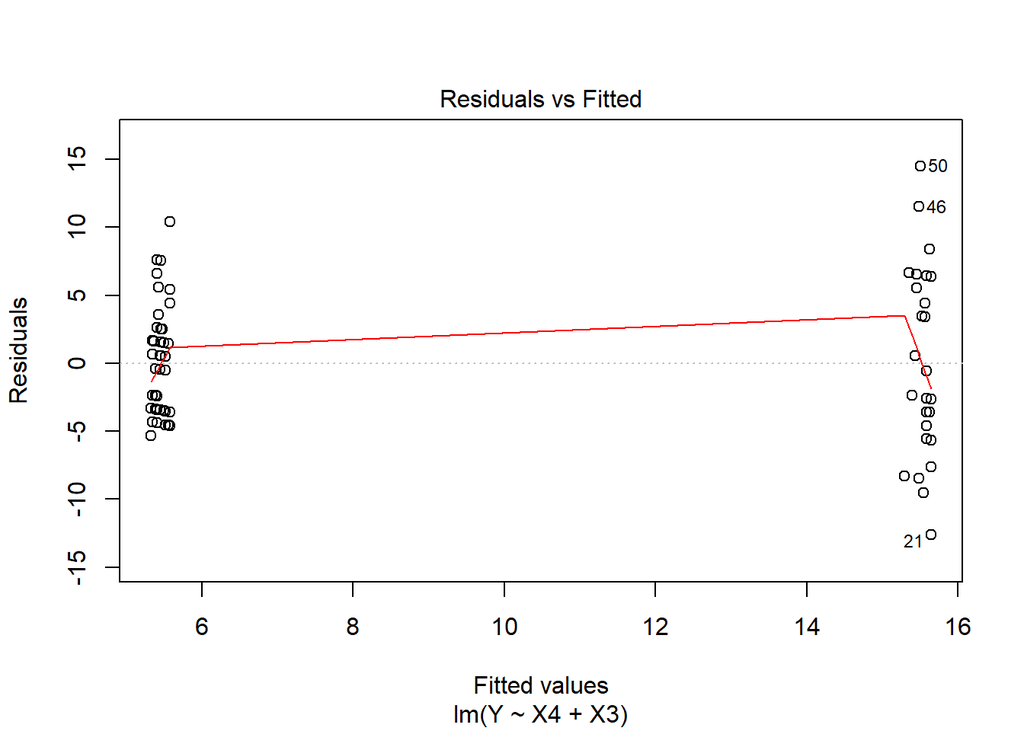

```r
plot(p9.29.lm4, which=1)
```

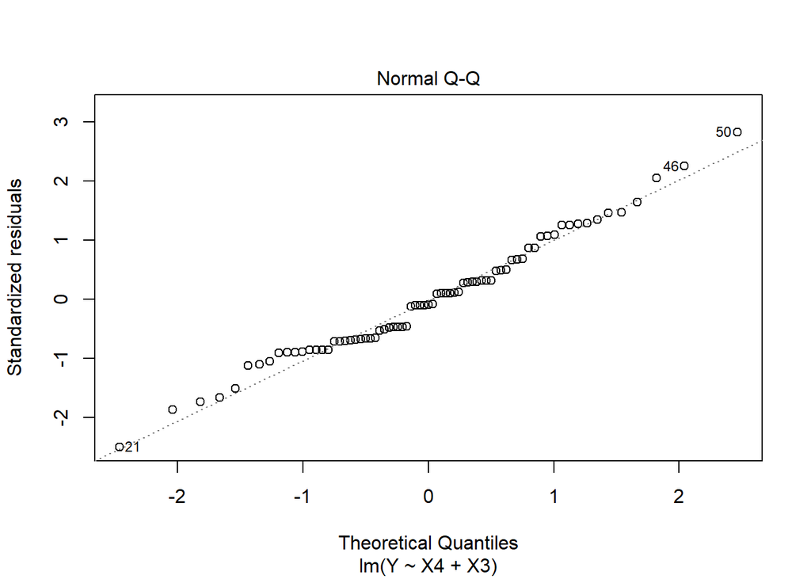

```r
plot(p9.29.lm4, which=2)
```

But that does not seem to add much either.

This plot seems to be explain some things.

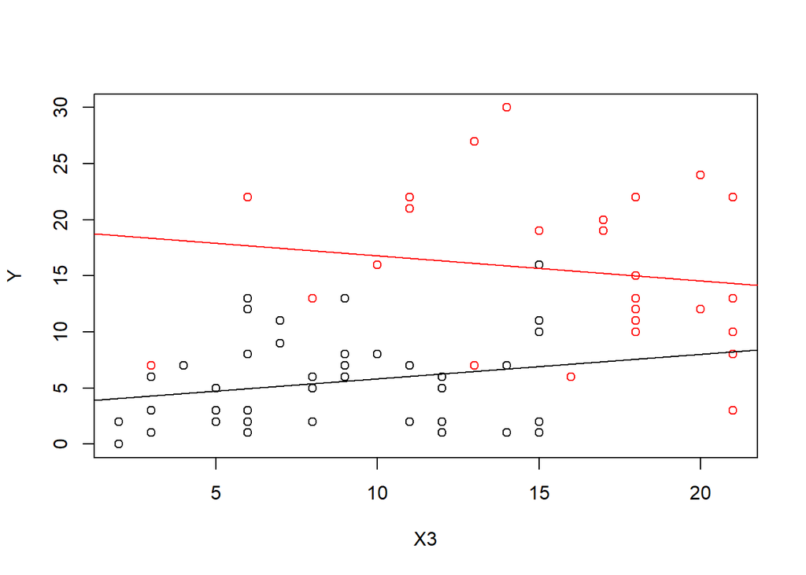

```r
p9.29.lm6 <- lm(Y ~ X3 + X4 + X4:X3,data=p9.29)
plot(Y ~ X3, col=X4+1, data=p9.29)
b<- p9.29.lm6$coefficients
abline(b[1], b[2], col="black")
abline(b[1]+b[3], b[2]+b[4], col="red")
```

After quite a few other combinations this model seemed to work well.

```r
p9.29.lm5 <- lm(Y ~ X3 + X1 + X4 + X3:X1, data=p9.29)
summary(p9.29.lm5)
```

```
##
## Call:
## lm(formula = Y ~ X3 + X1 + X4 + X3:X1, data = p9.29)
##
## Residuals:
##     Min      1Q  Median      3Q     Max
## -11.248  -2.922  -0.756   3.038  12.331
##
## Coefficients:
##             Estimate Std. Error t value Pr(>|t|)
## (Intercept) -7.81015    3.96184  -1.971  0.05276 .
## X3           1.26691    0.45246   2.800  0.00664 **
## X1           0.57584    0.17442   3.301  0.00154 **
## X4          11.68553    1.61609   7.231 5.44e-10 ***
## X3:X1       -0.05084    0.01511  -3.365  0.00126 **
## ---
## Signif. codes:  0 '***' 0.001 '**' 0.01 '*' 0.05 '.' 0.1 ' ' 1
##
## Residual standard error: 4.865 on 68 degrees of freedom
## Multiple R-squared:  0.5545, Adjusted R-squared:  0.5282
## F-statistic: 21.16 on 4 and 68 DF,  p-value: 2.291e-11
```

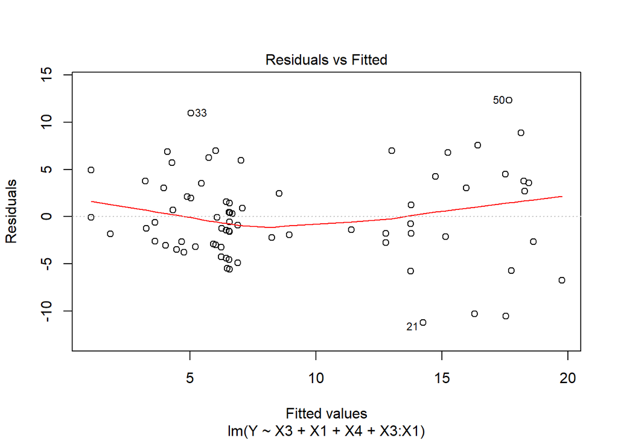

```r
plot(p9.29.lm5,which=1)
```

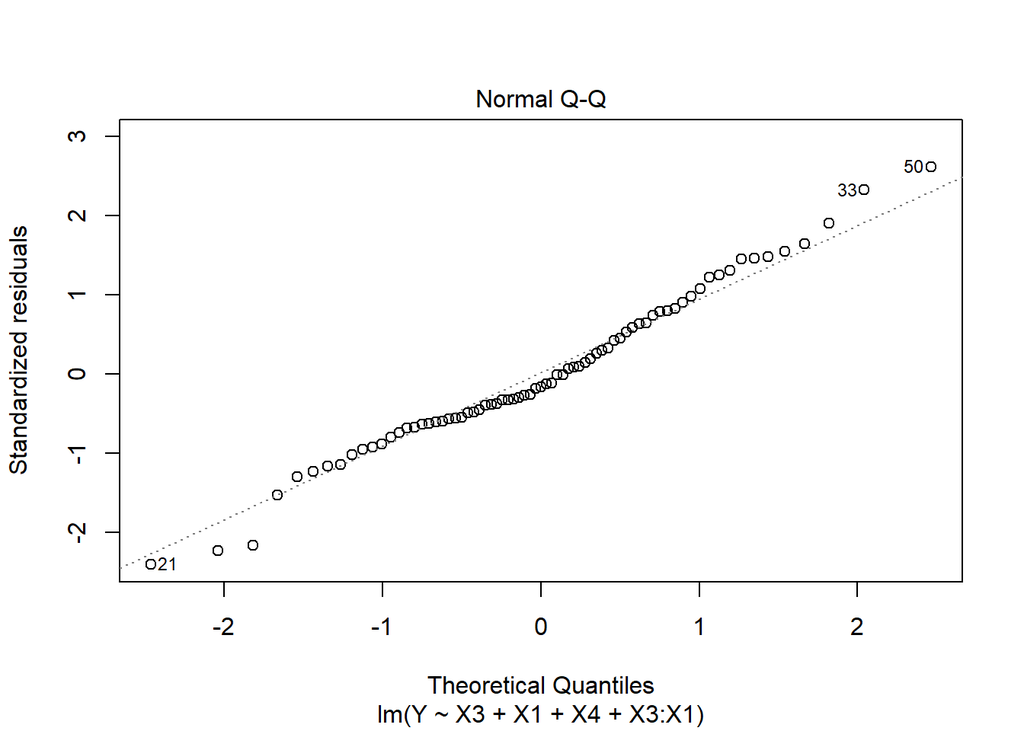

```r
plot(p9.29.lm5,which=2)
```

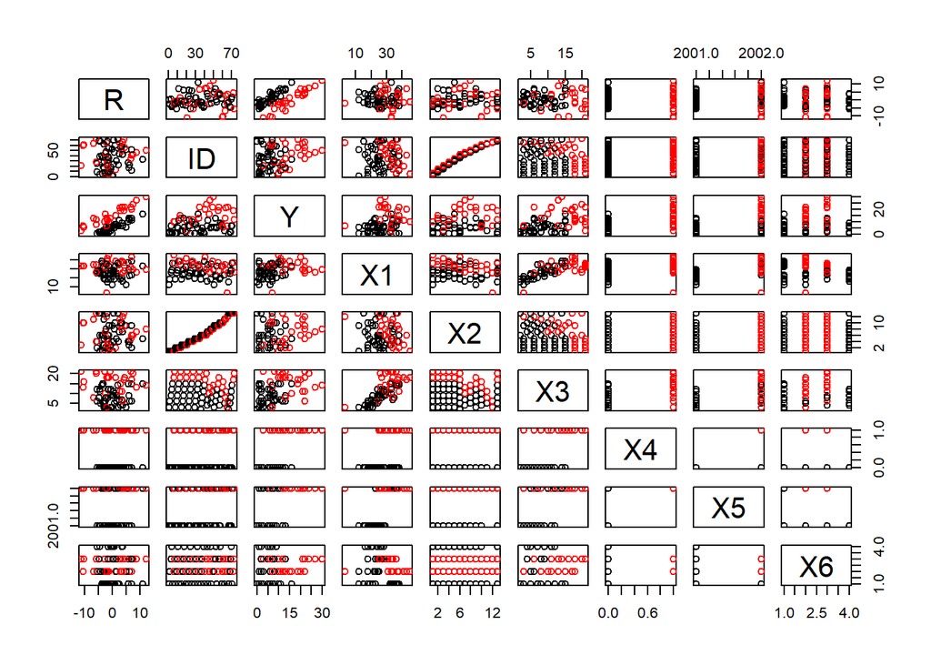

```r
pairs(cbind(R=p9.29.lm5$res, p9.29), col=as.factor(p9.29$X4))
```

This has the highest R2a value with the lowest residual standard error. This model is far more complex than just using X4 alone. But the residuals indicate that a slight non linearity and non constant variance. A transformation may be able to fix that.

Multicollinearity may be a problem in may model due to the high correlation between X1 and X3.

The last may be able to predict it better than the first model but it will be far more difficult to interpret, if its possible to.

It would be easier for a company to understand the first model compared to the later.

X4 does seem to have the most influencal variable but other ones such as X1, X3 and X5 are also discriptive in some way.

The correlation between X1 and X3 are interesting enough.

### Case Study 9.30 {10}{ / }

```r
# Code to read in the data
# It has to be merged from the 1.20 and 8.15 data files.
p9.30 <- read.table("http://www.stat.ufl.edu/~rrandles/sta4210/Rclassnotes/data/textdatasets/KutnerData/Appendix%20C%20Data%20Sets/APPENC05.txt", header=FALSE)

# Give it nice column names for conevience:
colnames(p9.30) <- c("ID","Y",paste("X",1:7, sep=""))

# Show the first part of the data:
#head(p9.30)
```